# MATH 118: Notes I

custom colors, labels

Before we start, check out: https://native-land.ca/

```r
#LOAD PACKAGES
library(tidyverse)
library(kableExtra)

#LOAD DATA SETS
can_lang <- read.csv("https://raw.githubusercontent.com/ttimbers/canlang/master/inst/extdata/can_lang.csv")
```

```r
plot1 <- can_lang %>%
  filter(most_at_home >0) %>%
  filter(mother_tongue >0) %>%
ggplot( aes(x=most_at_home, y=mother_tongue, color=category, shape=category)) +
  geom_point(alpha=0.7) +
  scale_y_log10(name = "Number of Canadians reporting the \n language as their mother tongue",
                labels = scales::comma) +
  scale_x_log10(name = "Number of Canadians speaking the language \n as their primary language at home",
                labels = scales::comma) +
  theme_minimal() +
  theme(legend.position="bottom")

plot1
```

[output not shown]

# Adding Labels (all points)

# Cree Languages

Suppose we are only interested in the Cree languages - a dialect of Algonquin languages. There are several listed in this dataset:

- Plains Cree
- Moose Cree
- Swampy Cree (sometimes divided into Eastern and Western Swampy Cree, but not in this dataset)
- Woods Cree
- Northern East Cree
- Southern East Cree
- Atikamekw
- Montagnais (Innu)
- Naskapi
- Cree, n.o.s. (not otherwise specified)

See them on a map here:

[Wikipedia - Cree Languages: https://upload.wikimedia.org/wikipedia/commons/thumb/9/9b/Cree_map.svg/1920px-Cree_map.png](https://upload.wikimedia.org/wikipedia/commons/thumb/9/9b/Cree_map.svg/1920px-Cree_map.png)

As with many aboriginal languages in Canada, there is a loss of the Cree languages among many speakers over the last few centuries.

Let’s say we only want to label on the graph the Cree languages on above plot. We need to create a new column which only contains the Cree languages, and is blank for all the other languages.

# Adding Labels (subset of points)

```r
#ifelse(condition, if condition is met do this, else do this)

can_lang <- can_lang %>%
  mutate(language_cree = ifelse(language == "Plains Cree"|
                                  language =="Moose Cree"|
                                  language == "Swampy Cree"|
                                  language == "Woods Cree"|
                                  language =="Northern East Cree"|
                                  language =="Southern East Cree"|
                                  language=="Atikamekw"|
                                  language == "Montagnais (Innu)"|
                                  language =="Naskapi"|
                                  language=="Cree, n.o.s.",language,""))
```

## Using `geom_text`

Note that we need to recreate the plot since the dataset `can_lang` has changed (we added column `language_cree`)

```r
plot1 <- can_lang %>%
  filter(most_at_home >0) %>%
  filter(mother_tongue >0) %>%
ggplot( aes(x=most_at_home, y=mother_tongue, color=category, shape=category)) +
  geom_point(alpha=0.7) +
  scale_y_log10(name = "Number of Canadians reporting the \n language as their mother tongue",labels = scales::comma) +
  scale_x_log10(name = "Number of Canadians speaking the language \n as their primary language at home",labels = scales::comma) +
  theme_minimal() +
  theme(legend.position="bottom")

plot1
```

[output not shown]

## Using `geom_text_repel` (requires `ggrepel` package)

```r
library(ggrepel)
plot1
```

[output not shown]

## Using `geom_label_repel` (requires `ggrepel` package)

```r
plot1
```

[output not shown]

# Customizing Colors

## Using Custom Colors

```r
plot1
```

[output not shown]

## Using Color Brewer

```r
library(RColorBrewer)
```

All ColorBrewer palettes:

[figure not shown]

```r
plot1
```

[output not shown]

# A Note About Color Blindness

It is important to consider how a color palette will look to people with common forms of color blindness:

- avoid red-green contrasts
- check your plots with systems that simulate color blindness.

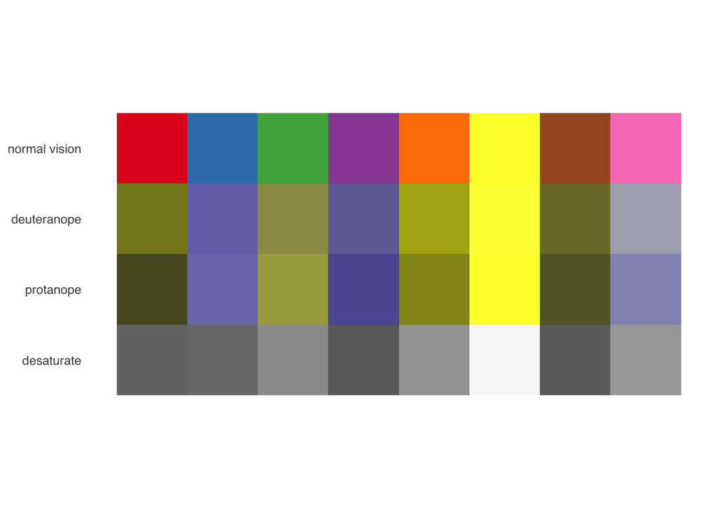

```r
library(colorBlindness)
displayAllColors(brewer.pal(name = "Set1", n = 8))
```

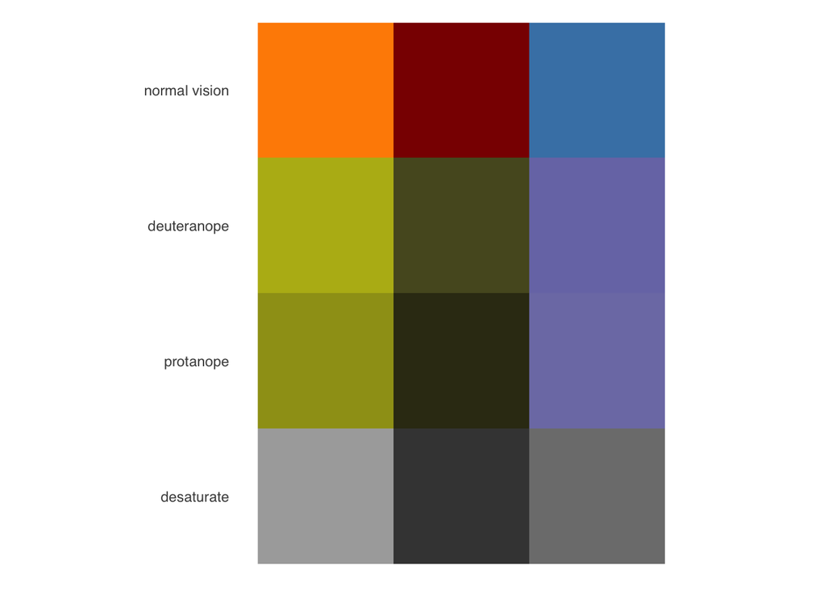

```r
displayAllColors(c("darkorange","darkred","steelblue"))
```